# Grid-level environmental maps

WM

2026-05-22

## Aim

These maps and distribution plots show the grid-level environmental variables used by the HMSC analysis. The map panels focus on Atlas 1 and Atlas 3, labelled here as the 1970s and 2010s. The violin plots include all three atlas periods so temporal shifts in the land-use distributions are visible.

The map style follows the avian bioregion cluster notebooks: each grid cell is drawn at its model coordinate, with mainland Denmark as the main panel and Bornholm shown as an inset.

## Dominant Land-Use Class

Dominance here is calculated only among the land-use predictors retained by the HMSC models: urban, cropland, pasture, forest, and grass/shrubland. The freshwater/saltwater percentage is omitted to match the model formula.

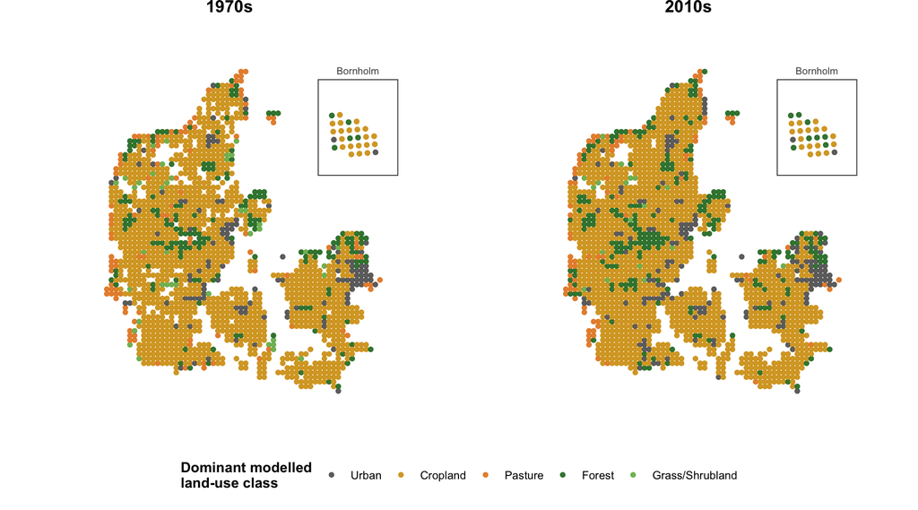

| period | dominant_model_land_use | n_cells | prop_cells |
| --- | --- | --- | --- |
| 1970s | Urban | 118 | 6.6% |
| 1970s | Cropland | 1327 | 74.7% |
| 1970s | Pasture | 105 | 5.9% |
| 1970s | Forest | 185 | 10.4% |
| 1970s | Grass/Shrubland | 41 | 2.3% |
| 1990s | Urban | 143 | 7.7% |
| 1990s | Cropland | 1353 | 73.1% |
| 1990s | Pasture | 97 | 5.2% |
| 1990s | Forest | 216 | 11.7% |
| 1990s | Grass/Shrubland | 41 | 2.2% |
| 2010s | Urban | 161 | 8.5% |
| 2010s | Cropland | 1399 | 73.5% |
| 2010s | Pasture | 84 | 4.4% |
| 2010s | Forest | 242 | 12.7% |
| 2010s | Grass/Shrubland | 18 | 0.9% |

## Land-Use Percentage Distributions Through Time

Each violin shows the distribution of grid-cell percentage cover for one land-use type within each atlas period. The y axis is the raw percentage cover of that land-use type in the grid cell.

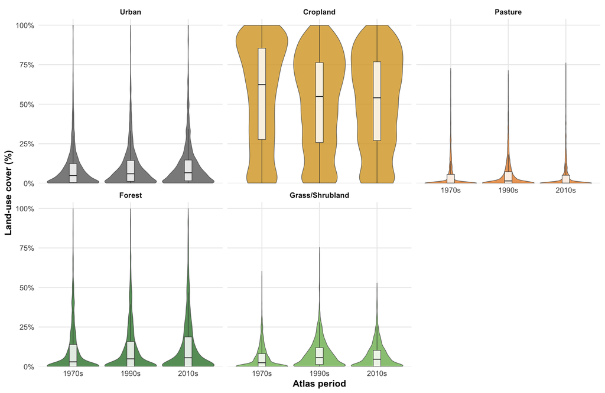

| period | land_use_type | n_cells | mean_percentage | median_percentage | q10_percentage | q90_percentage |
| --- | --- | --- | --- | --- | --- | --- |
| 1970s | Urban | 1776 | 9.87 | 4.87 | 0.00 | 25.78 |
| 1970s | Cropland | 1776 | 55.85 | 62.39 | 3.81 | 95.35 |
| 1970s | Pasture | 1776 | 5.13 | 0.00 | 0.00 | 16.66 |
| 1970s | Forest | 1776 | 10.40 | 2.99 | 0.00 | 32.84 |
| 1970s | Grass/Shrubland | 1776 | 5.44 | 2.43 | 0.00 | 15.76 |
| 1990s | Urban | 1850 | 10.80 | 6.01 | 0.00 | 27.80 |
| 1990s | Cropland | 1850 | 50.86 | 54.87 | 5.00 | 88.54 |
| 1990s | Pasture | 1850 | 5.70 | 1.47 | 0.00 | 17.05 |
| 1990s | Forest | 1850 | 11.64 | 4.87 | 0.00 | 33.74 |
| 1990s | Grass/Shrubland | 1850 | 8.07 | 5.62 | 0.00 | 20.01 |
| 2010s | Urban | 1904 | 11.45 | 6.66 | 0.00 | 29.67 |
| 2010s | Cropland | 1904 | 51.42 | 54.06 | 7.01 | 89.53 |
| 2010s | Pasture | 1904 | 4.69 | 0.00 | 0.00 | 15.00 |
| 2010s | Forest | 1904 | 12.85 | 5.57 | 0.00 | 37.09 |
| 2010s | Grass/Shrubland | 1904 | 6.75 | 4.62 | 0.00 | 17.68 |

## Zero-Inflated Land-Use Distribution View

The plot below separates the two parts of the distribution. The top panels show the percentage of grid cells where each land-use type is present at all. The bottom panels then show the percentage cover distribution only for cells where that land-use type is present. The bottom panels use free y axes because the sparse land-use types otherwise disappear against cropland’s 0-100% range.

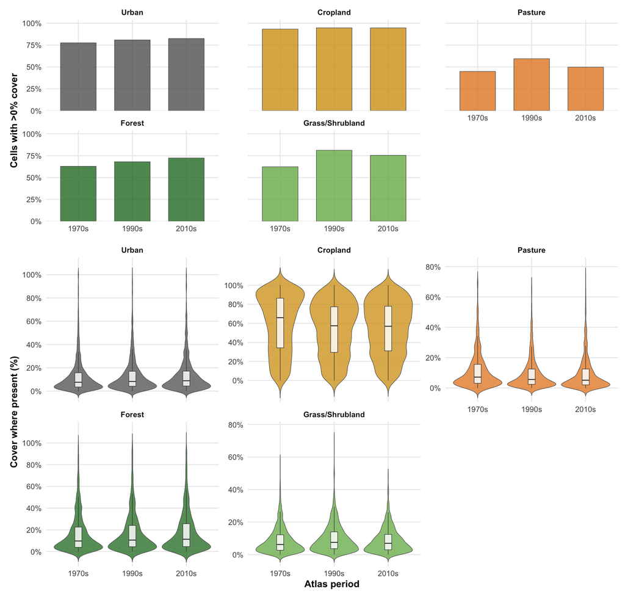

| period | land_use_type | n_cells | n_present | prop_present | mean_positive_percentage | median_positive_percentage | q10_positive_percentage | q90_positive_percentage |
| --- | --- | --- | --- | --- | --- | --- | --- | --- |
| 1970s | Urban | 1776 | 1377 | 77.5% | 12.73 | 7.59 | 1.63 | 30.59 |
| 1970s | Cropland | 1776 | 1656 | 93.2% | 59.89 | 66.00 | 14.33 | 96.06 |
| 1970s | Pasture | 1776 | 795 | 44.8% | 11.46 | 7.17 | 1.37 | 27.77 |
| 1970s | Forest | 1776 | 1116 | 62.8% | 16.55 | 9.74 | 1.58 | 41.49 |
| 1970s | Grass/Shrubland | 1776 | 1106 | 62.3% | 8.74 | 6.22 | 1.21 | 19.49 |
| 1990s | Urban | 1850 | 1496 | 80.9% | 13.35 | 8.29 | 1.81 | 31.26 |
| 1990s | Cropland | 1850 | 1751 | 94.6% | 53.74 | 57.51 | 12.03 | 89.01 |
| 1990s | Pasture | 1850 | 1098 | 59.4% | 9.61 | 5.62 | 1.09 | 24.47 |
| 1990s | Forest | 1850 | 1258 | 68.0% | 17.12 | 10.56 | 1.68 | 43.12 |
| 1990s | Grass/Shrubland | 1850 | 1501 | 81.1% | 9.94 | 7.52 | 1.78 | 21.68 |
| 2010s | Urban | 1904 | 1570 | 82.5% | 13.88 | 8.90 | 1.85 | 33.23 |
| 2010s | Cropland | 1904 | 1801 | 94.6% | 54.36 | 56.95 | 14.07 | 89.98 |
| 2010s | Pasture | 1904 | 946 | 49.7% | 9.45 | 5.13 | 0.70 | 24.33 |
| 2010s | Forest | 1904 | 1376 | 72.3% | 17.78 | 11.33 | 1.59 | 45.03 |
| 2010s | Grass/Shrubland | 1904 | 1436 | 75.4% | 8.94 | 6.95 | 1.30 | 19.28 |

## Land-Use Relative High-Low Maps

The maps below show whether each grid cell is lower or higher than the same-period distribution for that variable. Values are standardized within each `variable x period` combination before plotting, so the colours emphasize spatial high-low regions rather than raw units or period-level shifts.

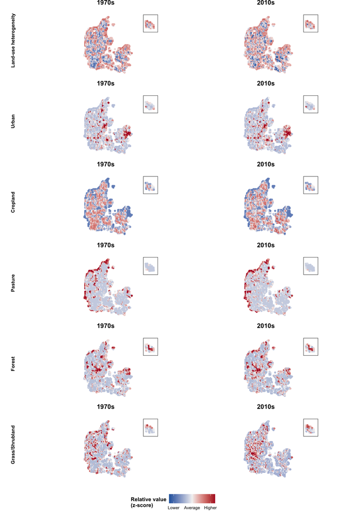

## Climate Relative High-Low Maps

These climate panels use the breeding-season temperature and precipitation variables included in the fitted models. As above, colours are relative to each period’s own spatial distribution.

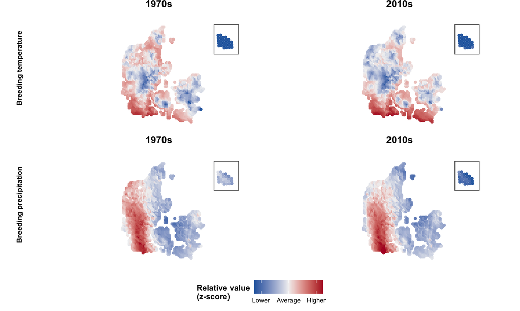

## Scaling Summary

| period | variable_label | mean_value | sd_value | q10 | q50 | q90 |
| --- | --- | --- | --- | --- | --- | --- |
| 1970s | Land-use heterogeneity | 0.434 | 0.229 | 0.083 | 0.481 | 0.712 |
| 1970s | Urban | 0.099 | 0.141 | 0.000 | 0.049 | 0.258 |
| 1970s | Cropland | 0.558 | 0.327 | 0.038 | 0.624 | 0.953 |
| 1970s | Pasture | 0.051 | 0.099 | 0.000 | 0.000 | 0.167 |
| 1970s | Forest | 0.104 | 0.162 | 0.000 | 0.030 | 0.328 |
| 1970s | Grass/Shrubland | 0.054 | 0.077 | 0.000 | 0.024 | 0.158 |
| 1970s | Breeding temperature | 8.395 | 0.192 | 8.195 | 8.417 | 8.590 |
| 1970s | Breeding precipitation | 128.360 | 12.291 | 113.729 | 126.201 | 146.434 |
| 1990s | Land-use heterogeneity | 0.493 | 0.195 | 0.193 | 0.532 | 0.713 |
| 1990s | Urban | 0.108 | 0.143 | 0.000 | 0.060 | 0.278 |
| 1990s | Cropland | 0.509 | 0.298 | 0.050 | 0.549 | 0.885 |
| 1990s | Pasture | 0.057 | 0.096 | 0.000 | 0.015 | 0.170 |
| 1990s | Forest | 0.116 | 0.170 | 0.000 | 0.049 | 0.337 |
| 1990s | Grass/Shrubland | 0.081 | 0.086 | 0.000 | 0.056 | 0.200 |
| 1990s | Breeding temperature | 8.290 | 0.219 | 8.049 | 8.272 | 8.607 |
| 1990s | Breeding precipitation | 199.237 | 15.160 | 179.452 | 198.830 | 220.615 |
| 2010s | Land-use heterogeneity | 0.488 | 0.198 | 0.177 | 0.529 | 0.711 |
| 2010s | Urban | 0.114 | 0.149 | 0.000 | 0.067 | 0.297 |
| 2010s | Cropland | 0.514 | 0.296 | 0.070 | 0.541 | 0.895 |
| 2010s | Pasture | 0.047 | 0.093 | 0.000 | 0.000 | 0.150 |
| 2010s | Forest | 0.128 | 0.176 | 0.000 | 0.056 | 0.371 |
| 2010s | Grass/Shrubland | 0.067 | 0.077 | 0.000 | 0.046 | 0.177 |
| 2010s | Breeding temperature | 9.559 | 0.196 | 9.347 | 9.551 | 9.833 |
| 2010s | Breeding precipitation | 204.771 | 21.153 | 181.804 | 200.874 | 236.123 |